# tmdb

## Investigating a Dataset:tmdb_movies data

### Introduction

The tmdb_movies dataset contain id , imdb_id , popularity , budget , revenue , original_title, cast , homepage, director tagline , keywords , overview , runtime , genres , production_companies , release_date , vote_count , vote_average release_year , budget_adj , revenue_adj.

Note:“_adj” show the budget and revenue of the associated movie in terms of 2010 dollars, accounting for inflation over time.

### Questions To Be Explored Here Are:

```
             1.How does vote_average is related to revenue?
             2.How does budgets,revenues and runtimes changes throughout different year?
             3.What kinds of properties are associated with movies that have high revenues?
             4.How does runtimes, budgets, revenues related to popularity over years?
             5.How many movies were release each year?
             6.In which year maximum movie were released and how much?
```

```python
#Load Useful Packages
import pandas as pd
import matplotlib.pyplot as plt
import numpy as np
import csv
import seaborn as sn
```

### Wrangling Phase:

```
         1.Data Acquisition
         2.Data clean
```

*Observations:*

```
     1.Row:10866
     2.Coloumn:21
     3.Null values present in variables:imdb_id , cast , homepage , director ,  tagline , keywords , overview ,
                                      genres , production_companies

     4.One Duplicate is row is there and it is deleted.
     5.id is unique for all rows and it can be used to identify all row uniquely.
```

```python
#load data
read = pd.read_csv('tmdb-movies.csv')

#display some data point
read.head()
```

|  | id | imdb_id | popularity | budget | revenue | original_title | cast | homepage | director | tagline | ... | overview | runtime | genres | production_companies | release_date | vote_count | vote_average | release_year | budget_adj | revenue_adj |
| --- | --- | --- | --- | --- | --- | --- | --- | --- | --- | --- | --- | --- | --- | --- | --- | --- | --- | --- | --- | --- | --- |
| 0 | 135397 | tt0369610 | 32.985763 | 150000000 | 1513528810 | Jurassic World | Chris Pratt\|Bryce Dallas Howard\|Irrfan Khan\|Vi... | http://www.jurassicworld.com/ | Colin Trevorrow | The park is open. | ... | Twenty-two years after the events of Jurassic ... | 124 | Action\|Adventure\|Science Fiction\|Thriller | Universal Studios\|Amblin Entertainment\|Legenda... | 6/9/15 | 5562 | 6.5 | 2015 | 1.379999e+08 | 1.392446e+09 |
| 1 | 76341 | tt1392190 | 28.419936 | 150000000 | 378436354 | Mad Max: Fury Road | Tom Hardy\|Charlize Theron\|Hugh Keays-Byrne\|Nic... | http://www.madmaxmovie.com/ | George Miller | What a Lovely Day. | ... | An apocalyptic story set in the furthest reach... | 120 | Action\|Adventure\|Science Fiction\|Thriller | Village Roadshow Pictures\|Kennedy Miller Produ... | 5/13/15 | 6185 | 7.1 | 2015 | 1.379999e+08 | 3.481613e+08 |
| 2 | 262500 | tt2908446 | 13.112507 | 110000000 | 295238201 | Insurgent | Shailene Woodley\|Theo James\|Kate Winslet\|Ansel... | http://www.thedivergentseries.movie/#insurgent | Robert Schwentke | One Choice Can Destroy You | ... | Beatrice Prior must confront her inner demons ... | 119 | Adventure\|Science Fiction\|Thriller | Summit Entertainment\|Mandeville Films\|Red Wago... | 3/18/15 | 2480 | 6.3 | 2015 | 1.012000e+08 | 2.716190e+08 |
| 3 | 140607 | tt2488496 | 11.173104 | 200000000 | 2068178225 | Star Wars: The Force Awakens | Harrison Ford\|Mark Hamill\|Carrie Fisher\|Adam D... | http://www.starwars.com/films/star-wars-episod... | J.J. Abrams | Every generation has a story. | ... | Thirty years after defeating the Galactic Empi... | 136 | Action\|Adventure\|Science Fiction\|Fantasy | Lucasfilm\|Truenorth Productions\|Bad Robot | 12/15/15 | 5292 | 7.5 | 2015 | 1.839999e+08 | 1.902723e+09 |
| 4 | 168259 | tt2820852 | 9.335014 | 190000000 | 1506249360 | Furious 7 | Vin Diesel\|Paul Walker\|Jason Statham\|Michelle ... | http://www.furious7.com/ | James Wan | Vengeance Hits Home | ... | Deckard Shaw seeks revenge against Dominic Tor... | 137 | Action\|Crime\|Thriller | Universal Pictures\|Original Film\|Media Rights ... | 4/1/15 | 2947 | 7.3 | 2015 | 1.747999e+08 | 1.385749e+09 |

5 rows × 21 columns

```python
#display info
read.info()
```

```
<class 'pandas.core.frame.DataFrame'>
RangeIndex: 10866 entries, 0 to 10865
Data columns (total 21 columns):
id                      10866 non-null int64
imdb_id                 10856 non-null object
popularity              10866 non-null float64
budget                  10866 non-null int64
revenue                 10866 non-null int64
original_title          10866 non-null object
cast                    10790 non-null object
homepage                2936 non-null object
director                10822 non-null object
tagline                 8042 non-null object
keywords                9373 non-null object
overview                10862 non-null object
runtime                 10866 non-null int64
genres                  10843 non-null object
production_companies    9836 non-null object
release_date            10866 non-null object
vote_count              10866 non-null int64
vote_average            10866 non-null float64
release_year            10866 non-null int64
budget_adj              10866 non-null float64
revenue_adj             10866 non-null float64
dtypes: float64(4), int64(6), object(11)
memory usage: 1.7+ MB
```

```python
print("The No. Of Duplicate Data:" + str(sum(read.duplicated())))
read[read.duplicated(keep = False)]
```

```
The No. Of Duplicate Data:1
```

|  | id | imdb_id | popularity | budget | revenue | original_title | cast | homepage | director | tagline | ... | overview | runtime | genres | production_companies | release_date | vote_count | vote_average | release_year | budget_adj | revenue_adj |
| --- | --- | --- | --- | --- | --- | --- | --- | --- | --- | --- | --- | --- | --- | --- | --- | --- | --- | --- | --- | --- | --- |
| 2089 | 42194 | tt0411951 | 0.59643 | 30000000 | 967000 | TEKKEN | Jon Foo\|Kelly Overton\|Cary-Hiroyuki Tagawa\|Ian... | NaN | Dwight H. Little | Survival is no game | ... | In the year of 2039, after World Wars destroy ... | 92 | Crime\|Drama\|Action\|Thriller\|Science Fiction | Namco\|Light Song Films | 3/20/10 | 110 | 5.0 | 2010 | 30000000.0 | 967000.0 |
| 2090 | 42194 | tt0411951 | 0.59643 | 30000000 | 967000 | TEKKEN | Jon Foo\|Kelly Overton\|Cary-Hiroyuki Tagawa\|Ian... | NaN | Dwight H. Little | Survival is no game | ... | In the year of 2039, after World Wars destroy ... | 92 | Crime\|Drama\|Action\|Thriller\|Science Fiction | Namco\|Light Song Films | 3/20/10 | 110 | 5.0 | 2010 | 30000000.0 | 967000.0 |

2 rows × 21 columns

```python
#remove duplicate row/rows
read.drop_duplicates(inplace = True)

#check all coloumn for null value
print(read.isnull().sum())

#check all ID value is unique or not
read.duplicated("id").count()
```

```
id                         0
imdb_id                   10
popularity                 0
budget                     0
revenue                    0
original_title             0
cast                      76
homepage                7929
director                  44
tagline                 2824
keywords                1493
overview                   4
runtime                    0
genres                    23
production_companies    1030
release_date               0
vote_count                 0
vote_average               0
release_year               0
budget_adj                 0
revenue_adj                0
dtype: int64
```

```
10865
```

```python
#Display some statistic about numeric variables.
read.describe()
```

|  | id | popularity | budget | revenue | runtime | vote_count | vote_average | release_year | budget_adj | revenue_adj |
| --- | --- | --- | --- | --- | --- | --- | --- | --- | --- | --- |
| count | 10865.000000 | 10865.000000 | 1.086500e+04 | 1.086500e+04 | 10865.000000 | 10865.000000 | 10865.000000 | 10865.000000 | 1.086500e+04 | 1.086500e+04 |
| mean | 66066.374413 | 0.646446 | 1.462429e+07 | 3.982690e+07 | 102.071790 | 217.399632 | 5.975012 | 2001.321859 | 1.754989e+07 | 5.136900e+07 |
| std | 92134.091971 | 1.000231 | 3.091428e+07 | 1.170083e+08 | 31.382701 | 575.644627 | 0.935138 | 12.813260 | 3.430753e+07 | 1.446383e+08 |
| min | 5.000000 | 0.000065 | 0.000000e+00 | 0.000000e+00 | 0.000000 | 10.000000 | 1.500000 | 1960.000000 | 0.000000e+00 | 0.000000e+00 |
| 25% | 10596.000000 | 0.207575 | 0.000000e+00 | 0.000000e+00 | 90.000000 | 17.000000 | 5.400000 | 1995.000000 | 0.000000e+00 | 0.000000e+00 |
| 50% | 20662.000000 | 0.383831 | 0.000000e+00 | 0.000000e+00 | 99.000000 | 38.000000 | 6.000000 | 2006.000000 | 0.000000e+00 | 0.000000e+00 |
| 75% | 75612.000000 | 0.713857 | 1.500000e+07 | 2.400000e+07 | 111.000000 | 146.000000 | 6.600000 | 2011.000000 | 2.085325e+07 | 3.370173e+07 |
| max | 417859.000000 | 32.985763 | 4.250000e+08 | 2.781506e+09 | 900.000000 | 9767.000000 | 9.200000 | 2015.000000 | 4.250000e+08 | 2.827124e+09 |

As *above* statistic shows that the minimum value for *budget,revenue,runtime,budget_adj,revenue_adj* is **0** which is not possible.It is there due to possibilty of missing those value so those place can't be empty.

**and** The best way to preserve the authenticity of dataset is to remove those rows in which *budget,revenue,runtime,budget_adj,revenue_adj* is **0** instead of using arbitrary values or some other specific values like mean of corresponding columns.

*Note:*If those places is replaced by some other values.It may changes the mean,standard deviation and some other parameter drastically.It may produce enormous error in data analyst process.

```python
#remove rows in which budget value is 0
read = read[read.budget != 0]

#remove rows in which revenue value is 0
read = read[read.revenue != 0]

#remove rows in which runtime value is 0
read = read[read.runtime != 0]

#remove rows in which budget_adj value is 0
read = read[read.budget_adj != 0]

#remove rows in which revenue_adj value is 0
read = read[read.revenue_adj != 0]
```

# dataset after wrangle phase

```python
#display info
read.info()
#display some data points
read.head()
```

```
<class 'pandas.core.frame.DataFrame'>
Int64Index: 3854 entries, 0 to 10848
Data columns (total 21 columns):
id                      3854 non-null int64
imdb_id                 3854 non-null object
popularity              3854 non-null float64
budget                  3854 non-null int64
revenue                 3854 non-null int64
original_title          3854 non-null object
cast                    3850 non-null object
homepage                1426 non-null object
director                3853 non-null object
tagline                 3574 non-null object
keywords                3716 non-null object
overview                3854 non-null object
runtime                 3854 non-null int64
genres                  3854 non-null object
production_companies    3808 non-null object
release_date            3854 non-null object
vote_count              3854 non-null int64
vote_average            3854 non-null float64
release_year            3854 non-null int64
budget_adj              3854 non-null float64
revenue_adj             3854 non-null float64
dtypes: float64(4), int64(6), object(11)
memory usage: 662.4+ KB
```

|  | id | imdb_id | popularity | budget | revenue | original_title | cast | homepage | director | tagline | ... | overview | runtime | genres | production_companies | release_date | vote_count | vote_average | release_year | budget_adj | revenue_adj |
| --- | --- | --- | --- | --- | --- | --- | --- | --- | --- | --- | --- | --- | --- | --- | --- | --- | --- | --- | --- | --- | --- |
| 0 | 135397 | tt0369610 | 32.985763 | 150000000 | 1513528810 | Jurassic World | Chris Pratt\|Bryce Dallas Howard\|Irrfan Khan\|Vi... | http://www.jurassicworld.com/ | Colin Trevorrow | The park is open. | ... | Twenty-two years after the events of Jurassic ... | 124 | Action\|Adventure\|Science Fiction\|Thriller | Universal Studios\|Amblin Entertainment\|Legenda... | 6/9/15 | 5562 | 6.5 | 2015 | 1.379999e+08 | 1.392446e+09 |
| 1 | 76341 | tt1392190 | 28.419936 | 150000000 | 378436354 | Mad Max: Fury Road | Tom Hardy\|Charlize Theron\|Hugh Keays-Byrne\|Nic... | http://www.madmaxmovie.com/ | George Miller | What a Lovely Day. | ... | An apocalyptic story set in the furthest reach... | 120 | Action\|Adventure\|Science Fiction\|Thriller | Village Roadshow Pictures\|Kennedy Miller Produ... | 5/13/15 | 6185 | 7.1 | 2015 | 1.379999e+08 | 3.481613e+08 |
| 2 | 262500 | tt2908446 | 13.112507 | 110000000 | 295238201 | Insurgent | Shailene Woodley\|Theo James\|Kate Winslet\|Ansel... | http://www.thedivergentseries.movie/#insurgent | Robert Schwentke | One Choice Can Destroy You | ... | Beatrice Prior must confront her inner demons ... | 119 | Adventure\|Science Fiction\|Thriller | Summit Entertainment\|Mandeville Films\|Red Wago... | 3/18/15 | 2480 | 6.3 | 2015 | 1.012000e+08 | 2.716190e+08 |
| 3 | 140607 | tt2488496 | 11.173104 | 200000000 | 2068178225 | Star Wars: The Force Awakens | Harrison Ford\|Mark Hamill\|Carrie Fisher\|Adam D... | http://www.starwars.com/films/star-wars-episod... | J.J. Abrams | Every generation has a story. | ... | Thirty years after defeating the Galactic Empi... | 136 | Action\|Adventure\|Science Fiction\|Fantasy | Lucasfilm\|Truenorth Productions\|Bad Robot | 12/15/15 | 5292 | 7.5 | 2015 | 1.839999e+08 | 1.902723e+09 |
| 4 | 168259 | tt2820852 | 9.335014 | 190000000 | 1506249360 | Furious 7 | Vin Diesel\|Paul Walker\|Jason Statham\|Michelle ... | http://www.furious7.com/ | James Wan | Vengeance Hits Home | ... | Deckard Shaw seeks revenge against Dominic Tor... | 137 | Action\|Crime\|Thriller | Universal Pictures\|Original Film\|Media Rights ... | 4/1/15 | 2947 | 7.3 | 2015 | 1.747999e+08 | 1.385749e+09 |

5 rows × 21 columns

```python
#Display some statistic about numeric variables.
read.describe()
```

|  | id | popularity | budget | revenue | runtime | vote_count | vote_average | release_year | budget_adj | revenue_adj |
| --- | --- | --- | --- | --- | --- | --- | --- | --- | --- | --- |
| count | 3854.000000 | 3854.000000 | 3.854000e+03 | 3.854000e+03 | 3854.000000 | 3854.000000 | 3854.000000 | 3854.000000 | 3.854000e+03 | 3.854000e+03 |
| mean | 39888.185262 | 1.191554 | 3.720370e+07 | 1.076866e+08 | 109.220291 | 527.720291 | 6.168163 | 2001.261028 | 4.423999e+07 | 1.370647e+08 |
| std | 67222.527399 | 1.475162 | 4.220822e+07 | 1.765393e+08 | 19.922820 | 879.956821 | 0.794920 | 11.282575 | 4.480925e+07 | 2.161114e+08 |
| min | 5.000000 | 0.001117 | 1.000000e+00 | 2.000000e+00 | 15.000000 | 10.000000 | 2.200000 | 1960.000000 | 9.693980e-01 | 2.370705e+00 |
| 25% | 6073.500000 | 0.462368 | 1.000000e+07 | 1.360003e+07 | 95.000000 | 71.000000 | 5.700000 | 1995.000000 | 1.309053e+07 | 1.835735e+07 |
| 50% | 11321.500000 | 0.797511 | 2.400000e+07 | 4.480000e+07 | 106.000000 | 204.000000 | 6.200000 | 2004.000000 | 3.001611e+07 | 6.173068e+07 |
| 75% | 38573.250000 | 1.368324 | 5.000000e+07 | 1.242125e+08 | 119.000000 | 580.000000 | 6.700000 | 2010.000000 | 6.061307e+07 | 1.632577e+08 |
| max | 417859.000000 | 32.985763 | 4.250000e+08 | 2.781506e+09 | 338.000000 | 9767.000000 | 8.400000 | 2015.000000 | 4.250000e+08 | 2.827124e+09 |

## Exploratory Data Analysis

**Ques1: How does *vote_average* is related to *revenue*?**

**Ans :Both variables have a little positve association to each other as Pearson correlation coefficient is equal to 0.2271.**

```
 Note: Pearson correlation coefficient can take a range of values from +1 to -1. 0 indicates that there
 is no relation between the two given variables. A value greater than 0 means a positive association.
 that is, as the value of one variable increases, so does the value of the other variable. A value less
 than 0 indicates a negative association.
```

```python
#vote_avg variable contain vote_average column dataset
vote_avg = read['vote_average']

#rev variable contain revenue column dataset
rev = read['revenue']

#pearson correlation coefficient
vote_std = (vote_avg - vote_avg.mean())/vote_avg.std(ddof = 0)
rev_std = (rev - rev.mean())/rev.std(ddof = 0)

pearson_c_cof = (vote_std * rev_std).mean()

print("Pearson correlation coefficient:" + str(pearson_c_cof))
```

```
Pearson correlation coefficient:0.227122775701683
```

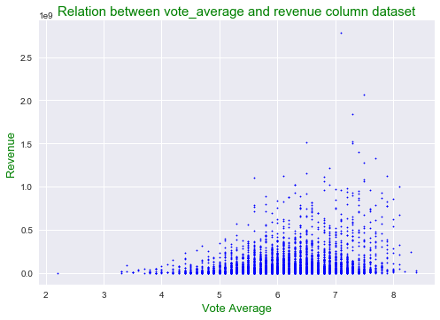

```python
#plot scatter plot between vote_average and revenue column dataset

plt.scatter(read["vote_average"],read["revenue"],s = 2,color ='b')
plt.title("Relation between vote_average and revenue column dataset",size = 15,color = 'g')
plt.xlabel("Vote Average",color = 'g',size = 13)
plt.ylabel("Revenue",color = 'g',size = 13)
plt.show()
```

**Ques2:How does budgets,revenues and runtimes changes throughout different year?**

**Ans:** *Observations:*

[output not shown]

```python
#find mean budget,revenue,runtime for different years
read.groupby('release_year')[['budget','revenue','runtime']].mean()
```

| release_year | budget | revenue | runtime |
| --- | --- | --- | --- |
| 1960 | 4.161390e+06 | 2.580100e+07 | 130.000000 |
| 1961 | 3.863700e+06 | 3.377202e+07 | 132.500000 |
| 1962 | 5.635714e+06 | 2.947569e+07 | 141.285714 |
| 1963 | 1.018583e+07 | 2.942115e+07 | 153.500000 |
| 1964 | 4.847880e+06 | 4.694479e+07 | 122.428571 |
| 1965 | 1.176000e+07 | 9.161637e+07 | 167.600000 |
| 1966 | 6.453600e+06 | 1.694734e+07 | 132.200000 |
| 1967 | 7.346154e+06 | 5.629497e+07 | 118.384615 |
| 1968 | 5.994444e+06 | 2.469131e+07 | 130.777778 |
| 1969 | 5.711022e+06 | 5.742677e+07 | 127.500000 |
| 1970 | 8.718359e+06 | 4.999745e+07 | 121.454545 |
| 1971 | 3.077077e+06 | 2.894513e+07 | 112.615385 |
| 1972 | 2.958032e+06 | 6.011252e+07 | 113.000000 |
| 1973 | 4.777250e+06 | 9.291776e+07 | 111.916667 |
| 1974 | 5.352692e+06 | 5.539746e+07 | 122.000000 |
| 1975 | 4.122222e+06 | 9.392303e+07 | 119.333333 |
| 1976 | 8.033333e+06 | 4.999510e+07 | 118.333333 |
| 1977 | 7.307895e+06 | 9.906097e+07 | 108.789474 |
| 1978 | 9.774707e+06 | 6.889824e+07 | 122.882353 |
| 1979 | 1.441875e+07 | 7.381438e+07 | 115.437500 |
| 1980 | 1.391522e+07 | 5.748329e+07 | 113.304348 |
| 1981 | 9.725000e+06 | 5.373338e+07 | 105.133333 |
| 1982 | 1.322692e+07 | 8.290986e+07 | 112.653846 |
| 1983 | 1.565248e+07 | 6.420325e+07 | 107.677419 |
| 1984 | 1.364398e+07 | 5.729726e+07 | 108.619048 |
| 1985 | 1.454331e+07 | 5.519938e+07 | 104.658537 |
| 1986 | 1.310625e+07 | 4.780115e+07 | 105.125000 |
| 1987 | 1.323761e+07 | 5.994515e+07 | 103.304348 |
| 1988 | 1.427719e+07 | 5.485749e+07 | 104.543860 |
| 1989 | 1.898018e+07 | 8.964569e+07 | 106.705882 |
| 1990 | 2.257794e+07 | 8.776483e+07 | 108.207547 |
| 1991 | 2.630000e+07 | 8.726243e+07 | 109.720000 |
| 1992 | 2.289293e+07 | 9.596928e+07 | 112.830189 |
| 1993 | 2.223174e+07 | 8.578492e+07 | 111.236111 |
| 1994 | 2.933560e+07 | 1.052128e+08 | 109.274194 |
| 1995 | 3.235086e+07 | 1.015866e+08 | 111.543210 |
| 1996 | 3.468247e+07 | 8.975952e+07 | 109.639535 |
| 1997 | 4.475874e+07 | 1.156503e+08 | 114.722222 |
| 1998 | 4.295663e+07 | 1.002843e+08 | 111.271739 |
| 1999 | 4.239461e+07 | 9.785331e+07 | 109.043103 |
| 2000 | 4.565283e+07 | 1.033016e+08 | 109.169811 |
| 2001 | 4.319239e+07 | 1.094903e+08 | 109.008264 |
| 2002 | 4.256567e+07 | 1.134679e+08 | 106.976378 |
| 2003 | 4.591601e+07 | 1.219669e+08 | 107.966942 |
| 2004 | 4.532789e+07 | 1.121477e+08 | 106.904762 |
| 2005 | 4.190764e+07 | 9.871410e+07 | 109.717791 |
| 2006 | 4.091253e+07 | 9.254744e+07 | 108.189349 |
| 2007 | 4.214890e+07 | 1.129738e+08 | 107.830303 |
| 2008 | 4.262010e+07 | 1.135385e+08 | 108.161677 |
| 2009 | 4.332085e+07 | 1.241789e+08 | 107.000000 |
| 2010 | 4.754572e+07 | 1.224964e+08 | 106.702247 |
| 2011 | 4.241985e+07 | 1.176294e+08 | 106.170854 |
| 2012 | 4.802285e+07 | 1.530662e+08 | 107.196203 |
| 2013 | 4.759957e+07 | 1.352815e+08 | 109.138889 |
| 2014 | 4.481072e+07 | 1.458786e+08 | 109.296970 |
| 2015 | 4.481736e+07 | 1.637683e+08 | 110.868750 |

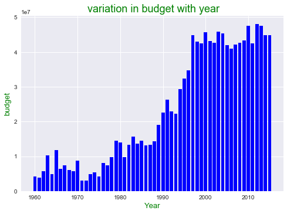

```python
#plot bar graph for mean budget for different years
year_budget = read.groupby('release_year')['budget'].mean()

plt.bar(year_budget.index,year_budget,color = 'b')
plt.title(" variation in budget with year",size = 18,color = 'g')
plt.xlabel("Year",size = 13,color = 'g')
plt.ylabel("budget",size = 13,color = 'g')
plt.show()
```

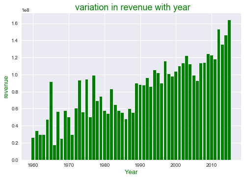

```python
#plot bar graph for mean revenue for different years
year_budget = read.groupby('release_year')['revenue'].mean()

plt.bar(year_budget.index,year_budget,color = 'g')
plt.title(" variation in revenue with year",size = 18,color = 'g')
plt.xlabel("Year",size = 13,color = 'g')
plt.ylabel("revenue",size = 13,color = 'g')
plt.show()
```

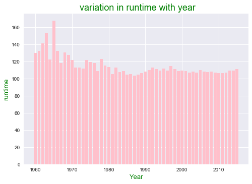

```python
#plot bar graph for mean runtime for different years
year_budget = read.groupby('release_year')['runtime'].mean()

plt.bar(year_budget.index,year_budget,color = 'pink')
plt.title(" variation in runtime with year",size = 18,color = 'g')
plt.xlabel("Year",size = 13,color = 'g')
plt.ylabel("runtime",size = 13,color = 'g')
plt.show()
```

**Ques3. What kinds of properties are associated with movies that have high revenues?**

**Ans:** observations:

```
                                                              Pearson correlation coefficient
        1.High revenue has positive association with popularity:   0.62
        2.High revenue has positive association with budget:       0.69
        3.High revenue has positive association with vote_count:   0.75
```

```python
# Pearson correlation coefficient
read.corr(method ='pearson')
```

|  | id | popularity | budget | revenue | runtime | vote_count | vote_average | release_year | budget_adj | revenue_adj |
| --- | --- | --- | --- | --- | --- | --- | --- | --- | --- | --- |
| id | 1.000000 | 0.188878 | -0.027449 | -0.003206 | -0.035688 | 0.111470 | -0.001269 | 0.489926 | -0.124035 | -0.088287 |
| popularity | 0.188878 | 1.000000 | 0.446987 | 0.615535 | 0.215092 | 0.780096 | 0.317866 | 0.173278 | 0.399356 | 0.546959 |
| budget | -0.027449 | 0.446987 | 1.000000 | 0.688556 | 0.260977 | 0.556937 | 0.024169 | 0.268040 | 0.958520 | 0.533498 |
| revenue | -0.003206 | 0.615535 | 0.688556 | 1.000000 | 0.250298 | 0.754567 | 0.227123 | 0.139140 | 0.657567 | 0.900882 |
| runtime | -0.035688 | 0.215092 | 0.260977 | 0.250298 | 1.000000 | 0.273771 | 0.351712 | -0.112453 | 0.333976 | 0.280505 |
| vote_count | 0.111470 | 0.780096 | 0.556937 | 0.754567 | 0.273771 | 1.000000 | 0.387210 | 0.207191 | 0.497970 | 0.654688 |
| vote_average | -0.001269 | 0.317866 | 0.024169 | 0.227123 | 0.351712 | 0.387210 | 1.000000 | -0.134246 | 0.036803 | 0.266844 |
| release_year | 0.489926 | 0.173278 | 0.268040 | 0.139140 | -0.112453 | 0.207191 | -0.134246 | 1.000000 | 0.075103 | -0.103147 |
| budget_adj | -0.124035 | 0.399356 | 0.958520 | 0.657567 | 0.333976 | 0.497970 | 0.036803 | 0.075103 | 1.000000 | 0.570451 |
| revenue_adj | -0.088287 | 0.546959 | 0.533498 | 0.900882 | 0.280505 | 0.654688 | 0.266844 | -0.103147 | 0.570451 | 1.000000 |

**Ques4:How does runtimes, budgets, revenues related to popularity over years?**

**Ans:** Observations:

```
        It can be seen from ABOVE Pearson correlation coefficient chart and from BELOW scatter plot .

                                                                                Pearson correlation coefficient
        1.Runtime has little positive association with popularity over years. :  0.22
        2.Budget has positive association with popularity over years.:           0.45
        3.Revenue has positive association with popularity over years.           0.62


      Note:  runtimes, budgets, revenues more or less correlate to popularity because increase in value of one
             variable,so does in value of  another variable and vice-versa.
```

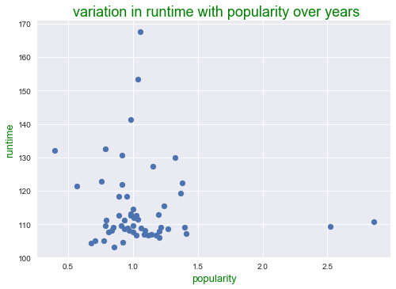

```python
#use average popularity and average runtime for different years to reduce the data point on scatter plot
avg_popularity = read.groupby('release_year')['popularity'].mean()
avg_runtime = read.groupby('release_year')['runtime'].mean()

plt.scatter(avg_popularity,avg_runtime)
plt.title(" variation in runtime with popularity over years",size = 18,color = 'g')
plt.xlabel("popularity",size = 13,color = 'g')
plt.ylabel("runtime",size = 13,color = 'g')
plt.show()
```

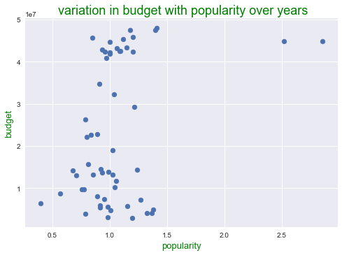

```python
#use average popularity and average budget for different years to reduce the data point on scatter plot
avg_popularity = read.groupby('release_year')['popularity'].mean()
avg_budget = read.groupby('release_year')['budget'].mean()

plt.scatter(avg_popularity,avg_budget)
plt.title(" variation in budget with popularity over years",size = 18,color = 'g')
plt.xlabel("popularity",size = 13,color = 'g')
plt.ylabel("budget",size = 13,color = 'g')
plt.show()
```

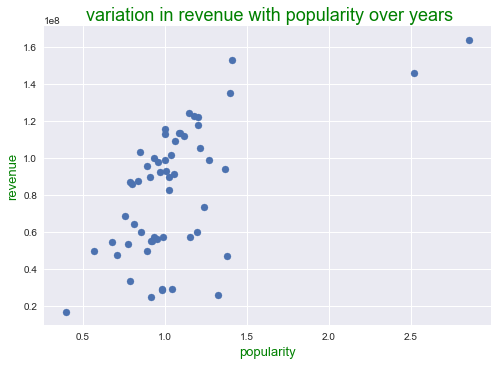

```python
#use average popularity and average revenue for different years to reduce the data point on scatter plot
avg_popularity = read.groupby('release_year')['popularity'].mean()
avg_revenue = read.groupby('release_year')['revenue'].mean()

plt.scatter(avg_popularity,avg_revenue)
plt.title(" variation in revenue with popularity over years",size = 18,color = 'g')
plt.xlabel("popularity",size = 13,color = 'g')
plt.ylabel("revenue",size = 13,color = 'g')
plt.show()
```

**Ques5:How many movies were release each year?**

**Ans:**

```
    Observations:
           No. of  movies which is getting release increases as we move right of bar graph.
```

```python
#movies release in different year
count_movies_yr = read.groupby('release_year')['release_year'].count()
print(count_movies_yr)
#find total no. of movie
total_movie = count_movies_yr.sum()
print("Total no. of movie:" ,str(total_movie))
```

```
release_year
1960      5
1961     10
1962      7
1963      6
1964      7
1965      5
1966      5
1967     13
1968      9
1969      4
1970     11
1971     13
1972      8
1973     12
```

[output cut: 44 more lines]

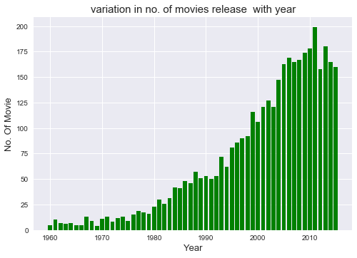

```python
plt.bar(count_movies_yr.index,count_movies_yr,color = 'g')
plt.title("variation in no. of movies release  with year", size = 15)
plt.xlabel("Year", size = 13)
plt.ylabel("No. Of Movie", size = 13)
plt.show()
```

**Ques6: In which year maximum movie were released and how much?**

**Ans:** Year:2011 and no. of movie:199

```python
#maximum no. of movie release in any year
val = read.groupby('release_year')['release_year'].count().max()
count_movies_yr[count_movies_yr == val] #count_movies_yr variable contains year as index with no. movie release in that year
```

```
release_year
2011    199
Name: release_year, dtype: int64
```

# Conclusion:

```
                1.There was one row which was duplicated one times in tmdb_movies dataset and duplicated row
                   get removed.

                2.Null values present in variables:imdb_id,cast,homepage,director,tagline,keywords, overview,
                  genres , production_companies.

                3.id is used to identifies row uniquely.

                4.There are different relationship exist among vote_average,revenue,popularity,runtimes
                  coloumns dataset.

                Limitations:

                   1.Many rows are remove from dataset due to  values 0 in budget,revenue,runtime,budget_adj
                     revenue_adj coloumns.This may  alter  many results like mean,standard deviation,many
                     different types of trends between variable. But it is best possible way to do.

                   2."Correalation doesn't imply causation ".In case of postive correlation between revenue
                      and popularity but it is possible that popularity is also effected by story of movies,
                      cast,genres,production companies etc.
```